# Analytics of Tweets by Trump

#Case study: Trump Tweets During the 2016 US presidential election, then-candidate Donald J. Trump used his Twitter account as a way to communicate with potential voters. On August 6, 2016 Todd Vaziri tweeted about Trump that “Every non-hyperbolic tweet is from iPhone (his staff). Every hyperbolic tweet is from Android (from him).” Data scientist David Robinson conducted an analysis to determine if data supported this assertion. Here we go through David’s analysis to learn some of the basics of text mining. To learn more about text mining in R we recommend this book.

We will use the following libraries

```r
library(tidyverse)
library(ggplot2)
library(lubridate)
library(tidyr)
library(scales)
set.seed(1)
```

In general, we can extract data directly from Twitter using the rtweet package. However, in this case, a group has already compiled data for us and made it available at http://www.trumptwitterarchive.com.

```r
url <- 'http://www.trumptwitterarchive.com/data/realdonaldtrump/%s.json'
trump_tweets <- map(2009:2017, ~sprintf(url, .x)) %>%
  map_df(jsonlite::fromJSON, simplifyDataFrame = TRUE) %>%
  filter(!is_retweet & !str_detect(text, '^"')) %>%
  mutate(created_at = parse_date_time(created_at, orders = "a b! d! H!:M!:S! z!* Y!", tz="EST"))
```

[output not shown]

For convenience we include the result of the code above in the dslabs package:

```r
library(dslabs)
data("trump_tweets")
```

This is data frame with information about the tweet:

```r
head(trump_tweets)
```

|  | source | id_str | text | created_at | retweet_count | in_reply_to_user_id_str | favorite_count | is_retweet |
| --- | --- | --- | --- | --- | --- | --- | --- | --- |
| 1 | Twitter Web Client | 6971079756 | From Donald Trump: Wishing everyone a wonderful holiday & a happy, healthy, prosperous New Year. Let’s think like champions in 2010! | 2009-12-23 12:38:18 | 28 | NA | 12 | FALSE |
| 2 | Twitter Web Client | 6312794445 | Trump International Tower in Chicago ranked 6th tallest building in world by Council on Tall Buildings & Urban Habitat http://bit.ly/sqvQq | 2009-12-03 14:39:09 | 33 | NA | 6 | FALSE |
| 3 | Twitter Web Client | 6090839867 | Wishing you and yours a very Happy and Bountiful Thanksgiving! | 2009-11-26 14:55:38 | 13 | NA | 11 | FALSE |
| 4 | Twitter Web Client | 5775731054 | Donald Trump Partners with TV1 on New Reality Series Entitled, Omarosa's Ultimate Merger: http://tinyurl.com/yk5m3lc | 2009-11-16 16:06:10 | 5 | NA | 3 | FALSE |
| 5 | Twitter Web Client | 5364614040 | --Work has begun, ahead of schedule, to build the greatest golf course in history: Trump International – Scotland. | 2009-11-02 09:57:56 | 7 | NA | 6 | FALSE |
| 6 | Twitter Web Client | 5203117820 | --From Donald Trump: "Ivanka and Jared’s wedding was spectacular, and they make a beautiful couple. I’m a very proud father." | 2009-10-27 10:31:48 | 4 | NA | 5 | FALSE |

The variables that are included are:

```r
names(trump_tweets)
```

```
[1] "source"                  "id_str"
[3] "text"                    "created_at"
[5] "retweet_count"           "in_reply_to_user_id_str"
[7] "favorite_count"          "is_retweet"
```

The help file ?trump_tweets provides details on what each variable represents. The tweets are represented by the text variable:

```r
trump_tweets %>% select(text) %>% head
```

|  | text |
| --- | --- |
| 1 | From Donald Trump: Wishing everyone a wonderful holiday & a happy, healthy, prosperous New Year. Let’s think like champions in 2010! |
| 2 | Trump International Tower in Chicago ranked 6th tallest building in world by Council on Tall Buildings & Urban Habitat http://bit.ly/sqvQq |
| 3 | Wishing you and yours a very Happy and Bountiful Thanksgiving! |
| 4 | Donald Trump Partners with TV1 on New Reality Series Entitled, Omarosa's Ultimate Merger: http://tinyurl.com/yk5m3lc |
| 5 | --Work has begun, ahead of schedule, to build the greatest golf course in history: Trump International – Scotland. |
| 6 | --From Donald Trump: "Ivanka and Jared’s wedding was spectacular, and they make a beautiful couple. I’m a very proud father." |

and the source variable tells us the device that was used to compose and upload each tweet:

```r
trump_tweets %>% count(source) %>% arrange(desc(n))
```

| source | n |
| --- | --- |
| Twitter Web Client | 10718 |
| Twitter for Android | 4652 |
| Twitter for iPhone | 3962 |
| TweetDeck | 468 |
| TwitLonger Beta | 288 |
| Instagram | 133 |
| Media Studio | 114 |
| Facebook | 104 |
| Twitter Ads | 96 |
| Twitter for BlackBerry | 78 |

[output cut: 9 more lines]

We can use extract to remove the Twitter for part of the source and filter out retweets.

```r
trump_tweets %>%
  extract(source, "source", "Twitter for (.*)") %>%
  count(source)
```

| source | n |
| --- | --- |
| Android | 4652 |
| BlackBerry | 78 |
| iPad | 39 |
| iPhone | 3962 |
| Websites | 1 |
| NA | 12029 |

We are interested in what happened during the campaign, so for the analysis here we will focus on what was tweeted between the day Trump announced his campaign and election day. So we define the following table:

```r
campaign_tweets <- trump_tweets %>%
  extract(source, "source", "Twitter for (.*)") %>%
  filter(source %in% c("Android", "iPhone") &
           created_at >= ymd("2015-06-17") &
           created_at < ymd("2016-11-08")) %>%
  filter(!is_retweet) %>%
  arrange(created_at)
```

We can now use data visualization to explore the possibility that two different groups were tweeting from these devices. For each tweet, we will extract the hour, in the east coast (EST), it was tweeted then compute the proportion of tweets tweeted at each hour for each device.

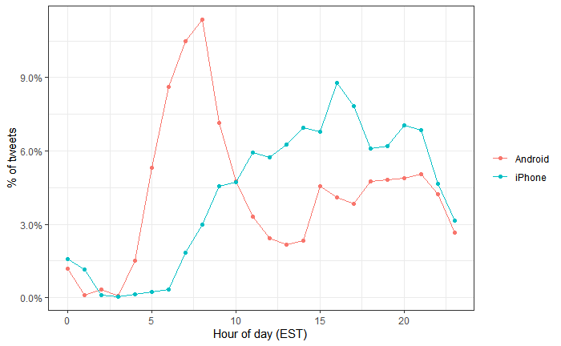

```r
ds_theme_set()
campaign_tweets %>%
  mutate(hour = hour(with_tz(created_at, "EST"))) %>%
  count(source, hour) %>%
  group_by(source) %>%
  mutate(percent = n / sum(n)) %>%
  ungroup %>%
  ggplot(aes(hour, percent, color = source)) +
  geom_line() +
  geom_point() +
  scale_y_continuous(labels = percent_format()) +
  labs(x = "Hour of day (EST)",
       y = "% of tweets",
       color = "")
```

We notice a big peak for the Android in early hours of the morning, between 6 and 8 AM. There seems to be a clear different in these patterns. We will therefore assume that two different entities are using these two devices. Now we will study how their tweets differ. To do this we introduce the tidytext package.

#Text as data The tidytext package helps us convert free from text into a tidy table. Having the data in this format greatly facilitates data visualization and applying statistical techniques.

```r
library(tidytext)
```

The main function needed to achieve this is unnest_tokens(). A token refers to the units that we are considering to be a data point. The most common tokens will be words, but they can also be single characters, ngrams, sentences, lines or a pattern defined by a regex. The functions will take a vector of strings and extract the tokens so that each one gets a row in the new table. Here is a simple example:

```r
example <- data_frame(line = c(1, 2, 3, 4),
                      text = c("Roses are red,", "Violets are blue,", "Sugar is sweet,", "And so are you."))
```

```
`data_frame()` is deprecated as of tibble 1.1.0.
Please use `tibble()` instead.
```

```r
example
```

| line | text |
| --- | --- |
| 1 | Roses are red, |
| 2 | Violets are blue, |
| 3 | Sugar is sweet, |
| 4 | And so are you. |

```r
example %>% unnest_tokens(word, text)
```

| line | word |
| --- | --- |
| 1 | roses |
| 1 | are |
| 1 | red |
| 2 | violets |
| 2 | are |
| 2 | blue |
| 3 | sugar |
| 3 | is |
| 3 | sweet |
| 4 | and |

[output cut: 3 more lines]

Now let’s look at a quick example with a tweet number 3008:

```r
i <- 3008
campaign_tweets$text[i]
```

```
[1] "Great to be back in Iowa! #TBT with @JerryJrFalwell joining me in Davenport- this past winter. #MAGA https://t.co/A5IF0QHnic"
```

```r
campaign_tweets[i,] %>%
  unnest_tokens(word, text) %>%
  select(word)
```

|  | word |
| --- | --- |
| 3008 | great |
| 3008.1 | to |
| 3008.2 | be |
| 3008.3 | back |
| 3008.4 | in |
| 3008.5 | iowa |
| 3008.6 | tbt |
| 3008.7 | with |
| 3008.8 | jerryjrfalwell |
| 3008.9 | joining |

[output cut: 10 more lines]

Note that the function tries to convert tokens into words and strips characters important to twitter such as # and @. A token in twitter is not the same as in regular English. For this reason, instead of using the default token, words, we define a regex that captures twitter character. The pattern appears complex but all we are defining is a patter that starts with @, # or neither and is followed by any combination of letters or digits:

```r
pattern <- "([^A-Za-z\\d#@']|'(?![A-Za-z\\d#@]))"
```

We can now use the unnest_tokens() function with the regex option and appropriately extract the hashtags and mentions:

```r
campaign_tweets[i,] %>%
  unnest_tokens(word, text, token = "regex", pattern = pattern) %>%
  select(word)
```

| word |
| --- |
| great |
| to |
| be |
| back |
| in |
| iowa |
| #tbt |
| with |
| @jerryjrfalwell |
| joining |

[output cut: 11 more lines]

Another minor adjustment we want to make is remove the links to pictures:

```r
campaign_tweets[i,] %>%
  mutate(text = str_replace_all(text, "https://t.co/[A-Za-z\\d]+|&amp;", ""))  %>%
  unnest_tokens(word, text, token = "regex", pattern = pattern) %>%
  select(word)
```

| word |
| --- |
| great |
| to |
| be |
| back |
| in |
| iowa |
| #tbt |
| with |
| @jerryjrfalwell |
| joining |

[output cut: 7 more lines]

Now we are ready to extract the words for all our tweets.

```r
tweet_words <- campaign_tweets %>%
  mutate(text = str_replace_all(text, "https://t.co/[A-Za-z\\d]+|&amp;", ""))  %>%
  unnest_tokens(word, text, token = "regex", pattern = pattern)
```

And we can now answer questions such as “what are the most commonly used words?”

```r
tweet_words %>%
  count(word) %>%
  arrange(desc(n))
```

| word | n |
| --- | --- |
| the | 2335 |
| to | 1413 |
| and | 1246 |
| a | 1210 |
| in | 1189 |
| i | 1161 |
| you | 1000 |
| of | 983 |
| is | 944 |
| on | 880 |

[output cut: 990 more lines]

It is not surprising that these are the top words. The top words are not informative. The tidytext package has database of these commonly used words, referred to as stop words, in text mining:

```r
stop_words
```

| word | lexicon |
| --- | --- |
| a | SMART |
| a's | SMART |
| able | SMART |
| about | SMART |
| above | SMART |
| according | SMART |
| accordingly | SMART |
| across | SMART |
| actually | SMART |
| after | SMART |

[output cut: 990 more lines]

If we filter out rows representing stop words with filter(!word %in% stop_words$word):

```r
tweet_words <- campaign_tweets %>%
  mutate(text = str_replace_all(text, "https://t.co/[A-Za-z\\d]+|&amp;", ""))  %>%
  unnest_tokens(word, text, token = "regex", pattern = pattern) %>%
  filter(!word %in% stop_words$word )
```

We end up with a much more informative set of top 10 tweeted words:

```r
tweet_words %>%
  count(word) %>%
  top_n(10, n) %>%
  mutate(word = reorder(word, n)) %>%
  arrange(desc(n))
```

| word | n |
| --- | --- |
| #trump2016 | 415 |
| hillary | 407 |
| people | 303 |
| #makeamericagreatagain | 296 |
| america | 254 |
| clinton | 239 |
| poll | 220 |
| crooked | 206 |
| trump | 199 |
| cruz | 162 |

Some exploration of the resulting words (not show here) reveals a couple of unwanted characteristics in our tokens. First, some of our tokens are just numbers (years for example). We want to remove these and we can find them using the regex ^$. Second, some of our tokens come from a quote and they start with ‘. We want to remove the’ when it’s at the start of a word, so we will use str_replace(). We add these two lines to the code above to generate our final table:

```r
tweet_words <- campaign_tweets %>%
  mutate(text = str_replace_all(text, "https://t.co/[A-Za-z\\d]+|&amp;", ""))  %>%
  unnest_tokens(word, text, token = "regex", pattern = pattern) %>%
  filter(!word %in% stop_words$word &
           !str_detect(word, "^\\d+$")) %>%
  mutate(word = str_replace(word, "^'", ""))
```

Now that we have all our words in a table, along with information about what device was used to compose the tweet they came from, we can start exploring which words are more common when comparing Android to iPhone.

For each word we want to know if it is more likely to come from an Android tweet or an iPhone tweet. We previously introduced the odds ratio, a summary statistic useful for quantifying these differences. For each device and a given word, let’s call it y, we compute the odds or the ratio between the proportion of words that are y and not y and compute the ratio of those odds. Here we will have many proportions that are 0 so we use the 0.5 correction.

```r
android_iphone_or <- tweet_words %>%
  count(word, source) %>%
  spread(source, n, fill = 0) %>%
  mutate(or = (Android + 0.5) / (sum(Android) - Android + 0.5) /
           ( (iPhone + 0.5) / (sum(iPhone) - iPhone + 0.5)))
android_iphone_or %>% arrange(desc(or))
```

| word | Android | iPhone | or |
| --- | --- | --- | --- |
| mails | 22 | 0 | 39.292266 |
| poor | 13 | 0 | 23.561945 |
| poorly | 12 | 0 | 21.815236 |
| @cbsnews | 11 | 0 | 20.068749 |
| bosses | 11 | 0 | 20.068749 |
| turnberry | 11 | 0 | 20.068749 |
| angry | 10 | 0 | 18.322482 |
| write | 10 | 0 | 18.322482 |
| brexit | 9 | 0 | 16.576436 |
| defend | 9 | 0 | 16.576436 |

[output cut: 990 more lines]

```r
android_iphone_or %>% arrange(or)
```

| word | Android | iPhone | or |
| --- | --- | --- | --- |
| #makeamericagreatagain | 0 | 296 | 0.001438868 |
| #americafirst | 0 | 71 | 0.006066172 |
| #draintheswamp | 0 | 63 | 0.006834394 |
| #trump2016 | 3 | 412 | 0.007178869 |
| #votetrump | 0 | 56 | 0.007685046 |
| join | 1 | 157 | 0.008210326 |
| #imwithyou | 0 | 51 | 0.008434234 |
| #crookedhillary | 0 | 30 | 0.014263160 |
| #fitn | 0 | 30 | 0.014263160 |
| #gopdebate | 0 | 30 | 0.014263160 |

[output cut: 990 more lines]

Given that several of these words are overall low frequency words we can impose a filter based on the total frequency like this:

```r
android_iphone_or %>% filter(Android+iPhone > 100) %>%
  arrange(desc(or))
```

| word | Android | iPhone | or |
| --- | --- | --- | --- |
| @cnn | 104 | 18 | 4.951435395 |
| bad | 104 | 26 | 3.454656330 |
| crooked | 157 | 49 | 2.792224365 |
| ted | 85 | 28 | 2.624630823 |
| interviewed | 76 | 25 | 2.623702669 |
| media | 77 | 26 | 2.557674284 |
| cruz | 116 | 46 | 2.193350283 |
| hillary | 290 | 119 | 2.140614127 |
| win | 74 | 30 | 2.135192446 |
| president | 84 | 35 | 2.081263102 |

[output cut: 20 more lines]

```r
android_iphone_or %>% filter(Android+iPhone > 100) %>%
  arrange(or)
```

| word | Android | iPhone | or |
| --- | --- | --- | --- |
| #makeamericagreatagain | 0 | 296 | 0.001438868 |
| #trump2016 | 3 | 412 | 0.007178869 |
| join | 1 | 157 | 0.008210326 |
| tomorrow | 25 | 101 | 0.217801814 |
| vote | 46 | 67 | 0.599501589 |
| america | 114 | 141 | 0.703427318 |
| tonight | 71 | 84 | 0.736615892 |
| iowa | 62 | 65 | 0.831349391 |
| poll | 117 | 103 | 0.989821637 |
| trump | 112 | 92 | 1.060915059 |

[output cut: 20 more lines]

We already see somewhat of a pattern in the types of words that are being tweeted more in one device versus the other. However, we are not interested in specific words but rather in the tone. Vaziri’s assertion is that the Android tweets are more hyperbolic. So how can we check this with data? Hyperbolic is a hard sentiment to extract from words as it relies on interpreting phrases. However, words can be associated to more basic sentiment such as as anger, fear, joy and surprise. In the next section we demonstrate basic sentiment analysis.

Sentiment Analysis In sentiment analysis we assign a word to one or more “sentiment”. Although this approach will miss context dependent sentiments, such as sarcasm, when performed on large numbers of words, summaries can provide insights.

The first step in sentiment analysis is to assign a sentiment to each word. The tidytext package includes several maps or lexicons in the object sentiments:

```r
sentiments
```

| word | sentiment |
| --- | --- |
| 2-faces | negative |
| abnormal | negative |
| abolish | negative |
| abominable | negative |
| abominably | negative |
| abominate | negative |
| abomination | negative |
| abort | negative |
| aborted | negative |
| aborts | negative |

[output cut: 990 more lines]

There are several lexicons in the tidytext package that give different sentiments. For example, the bing lexicon divides words into positive and negative. We can see this using the tidytext function get_sentiments():

```r
get_sentiments("bing")
```

| word | sentiment |
| --- | --- |
| 2-faces | negative |
| abnormal | negative |
| abolish | negative |
| abominable | negative |
| abominably | negative |
| abominate | negative |
| abomination | negative |
| abort | negative |
| aborted | negative |
| aborts | negative |

[output cut: 990 more lines]

The AFINN lexicon assigns a score between -5 and 5, with -5 the most negative and 5 the most positive.

```r
get_sentiments("afinn")
```

| word | value |
| --- | --- |
| abandon | -2 |
| abandoned | -2 |
| abandons | -2 |
| abducted | -2 |
| abduction | -2 |
| abductions | -2 |
| abhor | -3 |
| abhorred | -3 |
| abhorrent | -3 |
| abhors | -3 |

[output cut: 990 more lines]

The loughran and nrc lexicons provide several different sentiments:

```r
get_sentiments("loughran") %>% count(sentiment)
```

| sentiment | n |
| --- | --- |
| constraining | 184 |
| litigious | 904 |
| negative | 2355 |
| positive | 354 |
| superfluous | 56 |
| uncertainty | 297 |

```r
get_sentiments("nrc") %>% count(sentiment)
```

| sentiment | n |
| --- | --- |
| anger | 1247 |
| anticipation | 839 |
| disgust | 1058 |
| fear | 1476 |
| joy | 689 |
| negative | 3324 |
| positive | 2312 |
| sadness | 1191 |
| surprise | 534 |
| trust | 1231 |

To start learning about how these lexicons were developed, read this help file: ?sentiments.

For the analysis here we are interested in exploring the different sentiments of each tweet, so we will use the nrc lexicon:

```r
nrc <- get_sentiments("nrc") %>%
  select(word, sentiment)
```

We can combine the words and sentiments using inner_join(), which will only keep words associated with a sentiment. Here are 10 random words extracted from the tweets:

```r
tweet_words %>% inner_join(nrc, by = "word") %>%
  select(source, word, sentiment) %>% sample_n(10)
```

| source | word | sentiment |
| --- | --- | --- |
| Android | compliment | positive |
| iPhone | join | positive |
| iPhone | manage | trust |
| Android | worse | negative |
| Android | level | trust |
| iPhone | vote | positive |
| iPhone | watch | fear |
| iPhone | university | positive |
| iPhone | coincidence | surprise |
| iPhone | magnificent | joy |

Now we are ready to perform a quantitative analysis comparing Android and iPhone by comparing the sentiments of the tweets posted from each device. Here we could perform a tweet by tweet analysis, assigning a sentiment to each tweet. However, this somewhat complex since each tweet will have several sentiments attached to it, one for each word appearing in the lexicon. For illustrative purposes, we will perform a much simpler analysis: we will count and compare the frequencies of each sentiment appears for each device.

```r
sentiment_counts <- tweet_words %>%
  left_join(nrc, by = "word") %>%
  count(source, sentiment) %>%
  spread(source, n) %>%
  mutate(sentiment = replace_na(sentiment, replace = "none"))
sentiment_counts
```

| sentiment | Android | iPhone |
| --- | --- | --- |
| anger | 965 | 527 |
| anticipation | 915 | 710 |
| disgust | 641 | 318 |
| fear | 802 | 486 |
| joy | 698 | 540 |
| negative | 1668 | 935 |
| positive | 1834 | 1497 |
| sadness | 907 | 514 |
| surprise | 530 | 365 |
| trust | 1253 | 1010 |

[output cut: 1 more lines]

Because more words were used on the Android than on the phone:

```r
tweet_words %>% group_by(source) %>% summarize(n = n())
```

| source | n |
| --- | --- |
| Android | 15829 |
| iPhone | 13802 |

for each sentiment we can compute the odds of being in the device: proportion of words with sentiment versus proportion of words without and then compute the odds ratio comparing the two devices:

```r
sentiment_counts %>%
  mutate(Android = Android / (sum(Android) - Android) ,
         iPhone = iPhone / (sum(iPhone) - iPhone),
         or = Android/iPhone) %>%
  arrange(desc(or))
```

[output not shown]

So we do see some difference and the order is interesting: the largest three sentiments are disgust, anger, and negative! But are they statistically significant? How does this compare if we are just assigning sentiments at random?

To answer that question we can compute, for each sentiment, an odds ratio and confidence interval. We will add the two values we need to form a two-by-two table and the odds ratio:

```r
library(broom)
log_or <- sentiment_counts %>%
  mutate( log_or = log( (Android / (sum(Android) - Android)) / (iPhone / (sum(iPhone) - iPhone))),
          se = sqrt( 1/Android + 1/(sum(Android) - Android) + 1/iPhone + 1/(sum(iPhone) - iPhone)),
          conf.low = log_or - qnorm(0.975)*se,
          conf.high = log_or + qnorm(0.975)*se) %>%
  arrange(desc(log_or))

log_or
```

| sentiment | Android | iPhone | log_or | se | conf.low | conf.high |
| --- | --- | --- | --- | --- | --- | --- |
| disgust | 641 | 318 | 0.503977127 | 0.06935307 | 0.36804761 | 0.63990664 |
| anger | 965 | 527 | 0.411266612 | 0.05513963 | 0.30319493 | 0.51933829 |
| negative | 1668 | 935 | 0.395475483 | 0.04217497 | 0.31281405 | 0.47813691 |
| sadness | 907 | 514 | 0.372229104 | 0.05616457 | 0.26214858 | 0.48230963 |
| fear | 802 | 486 | 0.301815029 | 0.05839998 | 0.18735318 | 0.41627688 |
| surprise | 530 | 365 | 0.168013748 | 0.06878633 | 0.03319502 | 0.30283247 |
| joy | 698 | 540 | 0.049456578 | 0.05822822 | -0.06466864 | 0.16358179 |
| anticipation | 915 | 710 | 0.046843264 | 0.05107288 | -0.05325773 | 0.14694426 |
| trust | 1253 | 1010 | 0.007263495 | 0.04355609 | -0.07810488 | 0.09263187 |
| positive | 1834 | 1497 | -0.006235497 | 0.03640670 | -0.07759131 | 0.06512032 |

[output cut: 1 more lines]

A graphical visualization shows some sentiments that are clearly overrepresented:

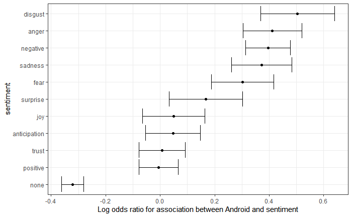

```r
log_or %>%
  mutate(sentiment = reorder(sentiment, log_or),) %>%
  ggplot(aes(x = sentiment, ymin = conf.low, ymax = conf.high)) +
  geom_errorbar() +
  geom_point(aes(sentiment, log_or)) +
  ylab("Log odds ratio for association between Android and sentiment") +
  coord_flip()
```

We see that the disgust, anger, negative sadness and fear sentiments are associated with the Android in a way that is hard to explain by chance alone. Words not associated to a sentiment were strongly associated with the iPhone source, which is in agreement with the original claim about hyperbolic tweets.

If we are interested in exploring which specific words are driving these differences, we can back to our android_iphone_or object:

```r
android_iphone_or %>% inner_join(nrc) %>%
  filter(sentiment == "disgust" & Android + iPhone > 10) %>%
  arrange(desc(or))
```

| word | Android | iPhone | or | sentiment |
| --- | --- | --- | --- | --- |
| mess | 15 | 2 | 5.4104208 | disgust |
| finally | 12 | 2 | 4.3624150 | disgust |
| unfair | 12 | 2 | 4.3624150 | disgust |
| bad | 104 | 26 | 3.4546563 | disgust |
| lie | 13 | 3 | 3.3652605 | disgust |
| terrible | 31 | 8 | 3.2358005 | disgust |
| lying | 9 | 3 | 2.3675475 | disgust |
| waste | 12 | 5 | 1.9824849 | disgust |
| phony | 21 | 9 | 1.9746888 | disgust |
| illegal | 32 | 14 | 1.9563386 | disgust |

[output cut: 10 more lines]

We can make a graph:

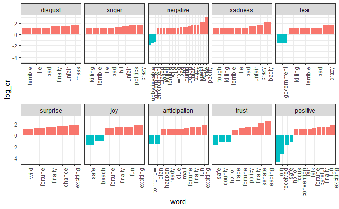

```r
android_iphone_or %>% inner_join(nrc, by = "word") %>%
  mutate(sentiment = factor(sentiment, levels = log_or$sentiment)) %>%
  mutate(log_or = log(or)) %>%
  filter(Android + iPhone > 10 & abs(log_or)>1) %>%
  mutate(word = reorder(word, log_or)) %>%
  ggplot(aes(word, log_or, fill = log_or < 0)) +
  facet_wrap(~sentiment, scales = "free_x", nrow = 2) +
  geom_bar(stat="identity", show.legend = FALSE) +
  theme(axis.text.x = element_text(angle = 90, hjust = 1))
```